# Human Memory

[figure not shown]

[figure not shown]

[figure not shown]

### About

We recently collected the Multimodal Memory Dataset in our lab. We collected up to 15 sessions per participant (n=3). In each session, participants learned and recalled image-word pairs. By manipulating how participants learn (encode) and recall image-word pairs, we are interested in how memory performance is affected by various conditions and individual differences in confidence as well as sleep quality. Our intended audience is the general memory researchers.

In the first page, we looked at how memory accuracy is related to people’s confidence. Is there a difference in memory accuracy based on how confident someone is in their responses?

In the second page, we looked at how memory performance varied as a function of repeated learning and delayed testing. How is memory accuracy affected by learning (encoding) and retrieval conditions?

In the third page, we investigated how sleep quality might affect memory performance. Does memory performance in our task vary with sleep quality?

# Accuracy vs. Confidence

### Current Version

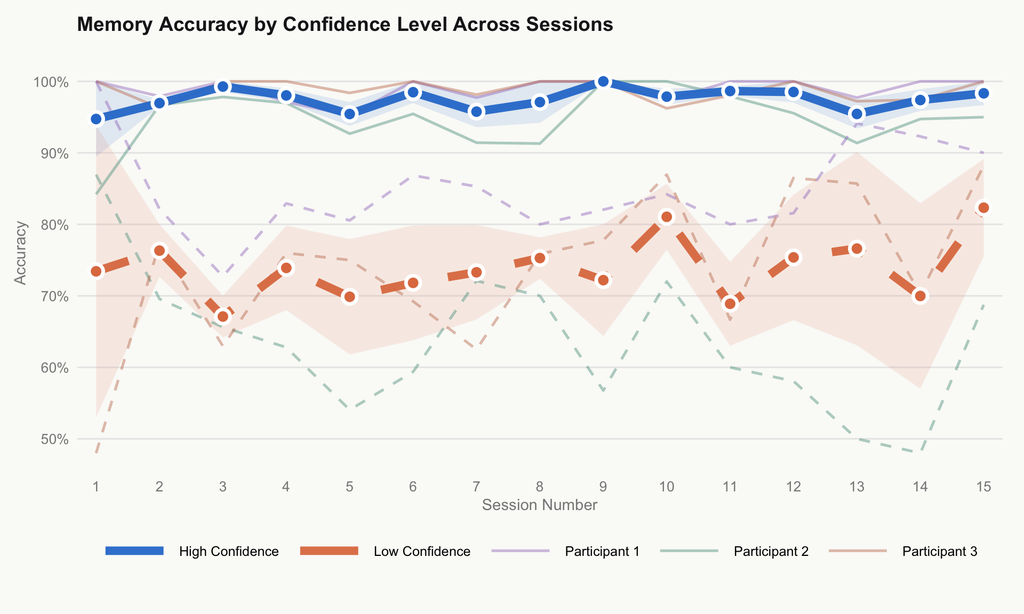

### About

# Accuracy vs. Memory Conditions

### Current Version

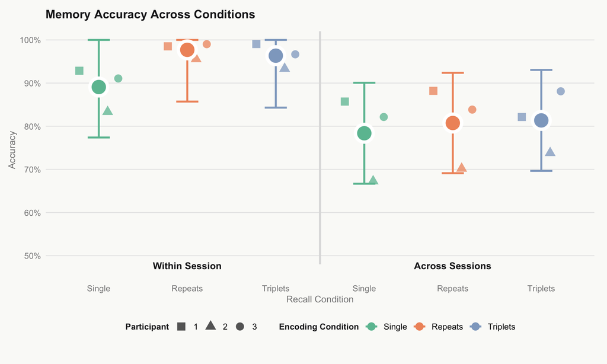

### About

# Accuracy vs. Sleep Quality

### Current Version

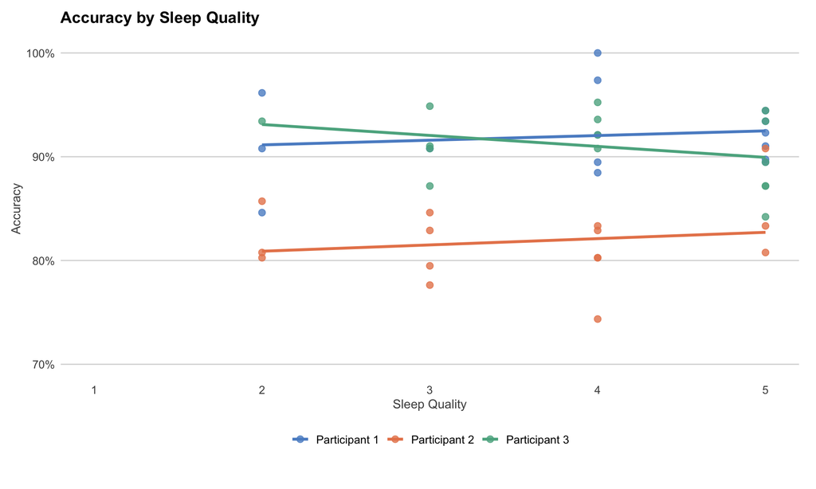